# lab3

## Univariate Linear Regression on the California Housing Prices Dataset

## 1. Framing The Problem

To unravel the mystery of house prices. We have three clues to help us: the average income of the residents, Population, and the number of households. By using a tool called Univariate Linear Regression, we’ll see how these clues relate to the price tag on the houses.

## 2- Getting The Data

```python
import pandas as pd

data= pd.read_csv('data/housing.csv')
```

## 3. Exploratory Data Analysis

3.1. Explore Statistics

```python
data.describe()
```

|  | longitude | latitude | housing_median_age | total_rooms | total_bedrooms | population | households | median_income | median_house_value |
| --- | --- | --- | --- | --- | --- | --- | --- | --- | --- |
| count | 20640.000000 | 20640.000000 | 20640.000000 | 20640.000000 | 20433.000000 | 20640.000000 | 20640.000000 | 20640.000000 | 20640.000000 |
| mean | -119.569704 | 35.631861 | 28.639486 | 2635.763081 | 537.870553 | 1425.476744 | 499.539680 | 3.870671 | 206855.816909 |
| std | 2.003532 | 2.135952 | 12.585558 | 2181.615252 | 421.385070 | 1132.462122 | 382.329753 | 1.899822 | 115395.615874 |
| min | -124.350000 | 32.540000 | 1.000000 | 2.000000 | 1.000000 | 3.000000 | 1.000000 | 0.499900 | 14999.000000 |
| 25% | -121.800000 | 33.930000 | 18.000000 | 1447.750000 | 296.000000 | 787.000000 | 280.000000 | 2.563400 | 119600.000000 |
| 50% | -118.490000 | 34.260000 | 29.000000 | 2127.000000 | 435.000000 | 1166.000000 | 409.000000 | 3.534800 | 179700.000000 |
| 75% | -118.010000 | 37.710000 | 37.000000 | 3148.000000 | 647.000000 | 1725.000000 | 605.000000 | 4.743250 | 264725.000000 |
| max | -114.310000 | 41.950000 | 52.000000 | 39320.000000 | 6445.000000 | 35682.000000 | 6082.000000 | 15.000100 | 500001.000000 |

3.2. Review the range of the data for each variable, and other issues you notice

```python
X_income = data[['median_income']]
X_population = data[['population']]
X_households = data[['households']]
y = data['median_house_value']

# Check for missing values
print(data.isnull().sum())

# Check the data types and statistics
print(data.dtypes)
```

```
longitude               0
latitude                0
housing_median_age      0
total_rooms             0
total_bedrooms        207
population              0
households              0
median_income           0
median_house_value      0
ocean_proximity         0
dtype: int64
longitude             float64
latitude              float64
housing_median_age    float64
total_rooms           float64
total_bedrooms        float64
population            float64
households            float64
median_income         float64
median_house_value    float64
ocean_proximity        object
dtype: object
```

3.3. Seaborn scatter plots

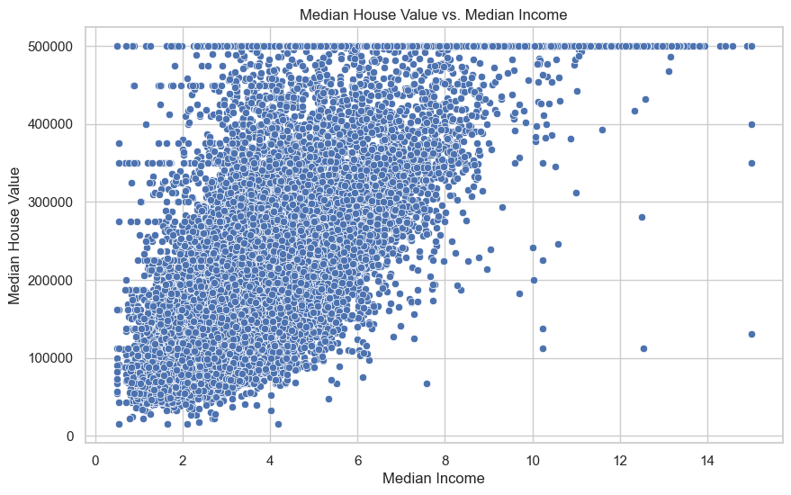

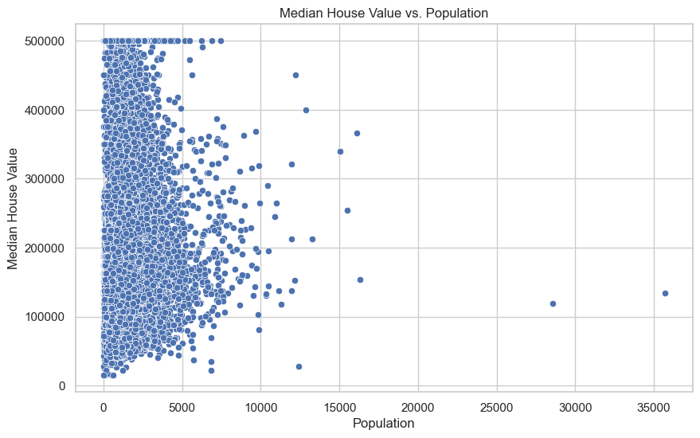

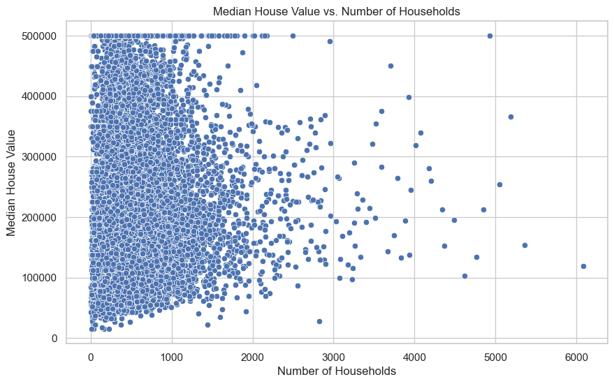

```python
# Set the style for the plots
sns.set(style="whitegrid")

# Scatter plot for median house value vs. median income
plt.figure(figsize=(10, 6))
sns.scatterplot(x='median_income', y='median_house_value', data=data)
plt.title('Median House Value vs. Median Income')
plt.xlabel('Median Income')
plt.ylabel('Median House Value')
plt.show()

# Scatter plot for median house value vs. population
plt.figure(figsize=(10, 6))
sns.scatterplot(x='population', y='median_house_value', data=data)
plt.title('Median House Value vs. Population')
plt.xlabel('Population')
plt.ylabel('Median House Value')
plt.show()

# Scatter plot for median house value vs. number of households
plt.figure(figsize=(10, 6))
sns.scatterplot(x='households', y='median_house_value', data=data)
plt.title('Median House Value vs. Number of Households')
plt.xlabel('Number of Households')
plt.ylabel('Median House Value')
plt.show()
```

## 4. Run three Linear Regressions

```python
from sklearn import linear_model
import pandas as pd
from sklearn.model_selection import train_test_split
from sklearn.linear_model import LinearRegression
from sklearn.metrics import mean_squared_error
import matplotlib.pyplot as plt

model = linear_model.LinearRegression()
```

Model 1: Median House value vs. Median Income

```python
X1 = data[['median_income']]
y1 = data['median_house_value']
X1_train, X1_test, y1_train, y1_test = train_test_split(X1, y1, test_size=0.4, random_state=56)

model1 = LinearRegression()
model1.fit(X1_train, y1_train)
```

```
LinearRegression()
```

Model 2: median house value vs. Population

```python
X2 = data[['population']]
y2 = data['median_house_value']
X2_train, X2_test, y2_train, y2_test = train_test_split(X2, y2, test_size=0.4, random_state=56)

model2 = LinearRegression()
model2.fit(X2_train, y2_train)
```

```
LinearRegression()
```

Model 3: Median House Value vs. Number of Households

```python
X3 = data[['households']]
y3 = data['median_house_value']
X3_train, X3_test, y3_train, y3_test = train_test_split(X3, y3, test_size=0.4, random_state=56)

model3 = LinearRegression()
model3.fit(X3_train, y3_train)
```

```
LinearRegression()
```

## 5. Table

Intercept and Slope, Mean Squared Error, Mean Absolute Error

```python
# Import necessary libraries
import pandas as pd
from sklearn.metrics import mean_squared_error, mean_absolute_error

# (model1, model2, model3)

# sample data for the test sets
X1_test, y1_test = X1, y1
X2_test, y2_test = X2, y2
X3_test, y3_test = X3, y3

# summary table
summary_table = pd.DataFrame({
    'Model': ['Model 1', 'Model 2', 'Model 3'],
    'Intercept': [model1.intercept_, model2.intercept_, model3.intercept_],



    'Slope': [model1.coef_[0], model2.coef_[0], model3.coef_[0]],
    'Mean Squared Error': [
        mean_squared_error(y1_test, model1.predict(X1_test)),
        mean_squared_error(y2_test, model2.predict(X2_test)),
        mean_squared_error(y3_test, model3.predict(X3_test))
    ],

    'Mean Absolute Error': [
        mean_absolute_error(y1_test, model1.predict(X1_test)),
        mean_absolute_error(y2_test, model2.predict(X2_test)),
        mean_absolute_error(y3_test, model3.predict(X3_test))
    ]
})

print(summary_table)
```

```
     Model      Intercept         Slope  Mean Squared Error
0  Model 1   45447.390134  41569.445741        7.011750e+09  \
1  Model 2  210461.763431     -2.637205        1.330746e+10
2  Model 3  196882.690629     19.721888        1.325779e+10

   Mean Absolute Error
0         62558.853580
1         91126.523802
2         90780.551869
```

## Table Summary

[output not shown]

## 6. Plot the resulting line on top of the scatter data for each of the three models

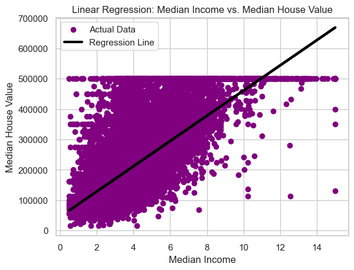

```python
# Plotting Model 1
import matplotlib.pyplot as plt
import numpy as np

# Assuming you have already trained three linear regression models (model1, model2, model3)

# Scatter plot for Model 1
plt.scatter(X1_test, y1_test, color='purple', label='Actual Data')
plt.plot(X1_test, model1.predict(X1_test), color='black', linewidth=3, label='Regression Line')
plt.title('Linear Regression: Median Income vs. Median House Value')
plt.xlabel('Median Income')
plt.ylabel('Median House Value')
plt.legend()
plt.show()
```

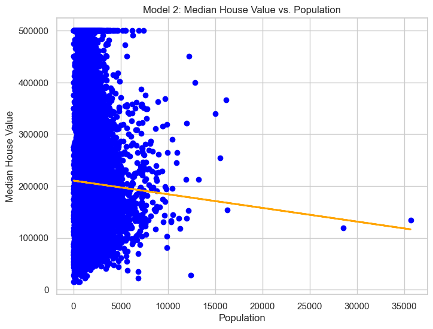

```python
# Plotting Model 2
plt.figure(figsize=(8, 6))
plt.scatter(X2_test, y2_test, color='blue')
plt.plot(X2_test, model2.predict(X2_test), color='orange', linewidth=2)
plt.title('Model 2: Median House Value vs. Population')
plt.xlabel('Population')
plt.ylabel('Median House Value')
plt.show()
```

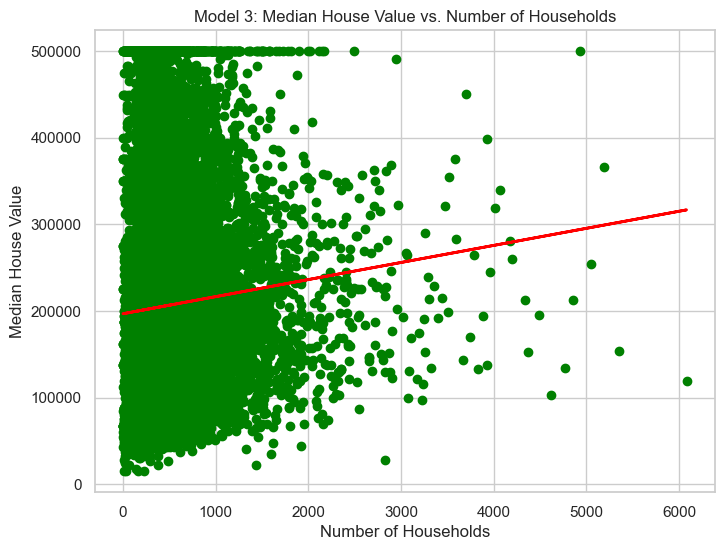

```python
# Plotting Model 3
plt.figure(figsize=(8, 6))
plt.scatter(X3_test, y3_test, color='green')
plt.plot(X3_test, model3.predict(X3_test), color='red', linewidth=2)
plt.title('Model 3: Median House Value vs. Number of Households')
plt.xlabel('Number of Households')
plt.ylabel('Median House Value')
plt.show()
```

## 7. Insights

Model 1: predicts median house value based on the median income, and has the lowest Mean Squared Error (MSE) and Mean Absolute Error (MAE). This suggests that median income is the most predictive of the three variables we considered and that this model best fits the data.

Model 2 and Model 3, which predict median house value based on population and number of households respectively, have significantly higher MSE and MAE values. This suggests that these models do not fit the data as well as Model 1. The high error values could be due to outliers, a non-linear relationship between the variables, or any other factors.

Conclusion

Based on the MSE and MAE values, median income appears to be the most reliable predictor of median house value among the variables we considered.